# Procesamiento de datos masivos con R y RStudio

Yolanda García Ruiz

23/09/2025

# 1 Ejercicios 2

## 1.1 Instrucciones

Para resolver estos ejercicios has de crear un script nuevo dentro de un proyecto R.

- Abre el proyecto que has descargado de la Escuela Virtual
- Comprueba que en la pestaña `Files` hay una carpeta llamada `tareas`.
- Crea un nuevo script de R `File -> New File -> R Script`. Pulsa el botón que te permite grabar el Script. Guárdalo en la carpeta `tareas`.

## 1.2 Resolver

1. Crea un vector `v1` con los números del 1 al 10.
2. Crea un vector `v2` como una secuencia de números del 5 al 50 con un incremento de 5 usando la función `seq`.
3. Escribe la expresión que calcula el tamaño del vector `v2`.
4. Escribe la instrucción que permite seleccionar cada una de las siguientes zonas sombreadas, del vector `b1.`

   ```r
   b1 <- c(10, 20, 30, 40, 50, 60, 70, 80)
   ```

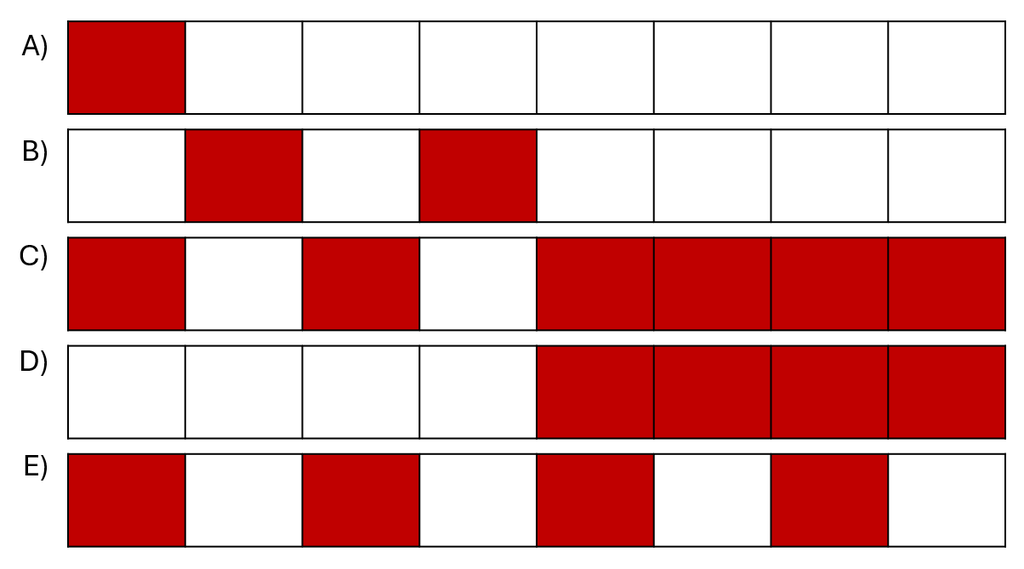

5. Genera un vector `a1` de 100 números enteros aleatorios entre 1 y 10 utilizando la función `sample()`. Busca ayuda en la pestaña `Help` para saber cómo se usa dicha función.
6. Genera un vector `a2` de 100 números aleatorios de una distribución normal estándar (media 0, desviación estándar 1) utilizando la función `rnorm()`. Posteriormente ejecuta la instrucción `hist(a2).`

   ```
   a2 <- ...
   hist(a2)
   ```

7. Calcula la suma de los vectores `a1` y `a2`
8. Con el vector `a1`, calcula los primeros estadísticos con la función `summary()`.
9. Con el vector `v3`,

   ```r
   v3 <- c(2,3, 6, 2, 4, 12, 3, 1, 7, 14, 6, 2, 8 ,13)
   ```

- selecciona los números pares menores que 10
- multiplica por 2 cada uno de los elementos del vector
- calcula la suma acumulada de los elementos del vector (`cumsum()` )

## 1.3 Ejercicios para trabajar en casa

1. Escribe la instrucción en R que permita cambiar el tipo del vector `v3` a tipo string. Usa alguna de las funciones de la familia `as.*`.
2. Divide los elementos del vector `v3` por $10^{20}$. Guarda el resultado en un nuevo vector llamado `v5`.
- Ejecuta `v5 == 0`
- Ejecuta `near(v5, 0)` y observa el resultado. La función `near()` pertenece al paquete `dplyr`.

  ```r
  library(dplyr)
  ```